# STATS 250 Lab 3

Lab Dream Team

Week of 9/14/2020

## Learning Objectives

### Statistical Learning Objectives

1. Practice interpreting histograms and boxplots
2. Revisit the five-number summary of a variable

### R Learning Objectives

1. Learn how to make a boxplot in R
2. Learn how to find a specific numeric summary in R
3. Learn how to make a histogram in R
4. Learn how to create a subset of a data set.

### Functions covered in this lab

1. `boxplot()`
2. `min()`, `mean()`, `median()`, `max()`, `sd()`, `IQR()`
3. `hist()`
4. `subset()`

### Weekly Advice

Lab 1 and Lab 2 are quickly and easily available to you. Our knowledge will continue to grow each week. Reviewing the prior weeks’ R functions prior to working on the next lab might be useful.

## Lab Tutorial

We’re back to hanging out with our penguin friends.

```r
penguins <- read.csv(url("https://raw.githubusercontent.com/STATS250SBI/palmerpenguins/master/inst/extdata/penguins_NArm.csv"))
```

### Boxplots in R

The command for making a boxplot in R is pretty simple: it’s just `boxplot()`. To make a boxplot of a single variable, just give R the name of the data set, a dollar sign ($), then the name of the variable. Also provide the arguments `main` and `ylab` for a plot title and y-axis label.

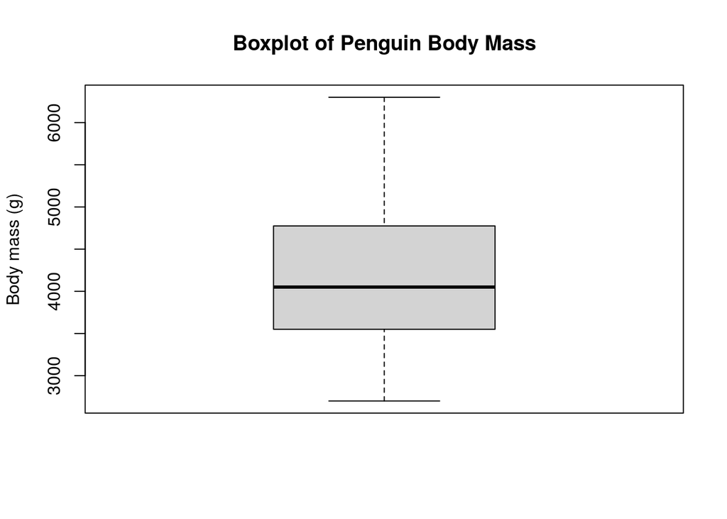

```r
boxplot(penguins$body_mass_g,
        main = "Boxplot of Penguin Body Mass",
        ylab = "Body mass (g)")
```

Remember that boxplots are a graphical representation of the “five-number summary” which we can get from the `summary()` function:

```r
summary(penguins$body_mass_g)
```

```
##    Min. 1st Qu.  Median    Mean 3rd Qu.    Max.
##    2700    3550    4050    4207    4775    6300
```

You can always get just the one numerical summary you’re looking for using the function for that specific summary:

```r
min(penguins$body_mass_g)
```

```
## [1] 2700
```

```r
mean(penguins$body_mass_g)
```

```
## [1] 4207.057
```

```r
median(penguins$body_mass_g)
```

```
## [1] 4050
```

```r
max(penguins$body_mass_g)
```

```
## [1] 6300
```

```r
sd(penguins$body_mass_g)
```

```
## [1] 805.2158
```

```r
IQR(penguins$body_mass_g)
```

```
## [1] 1225
```

Sometimes we’re interested in comparing two or more groups using “side-by-side” boxplots. We can compare the different species of penguins’ body masses in this way, still using the `boxplot` function.

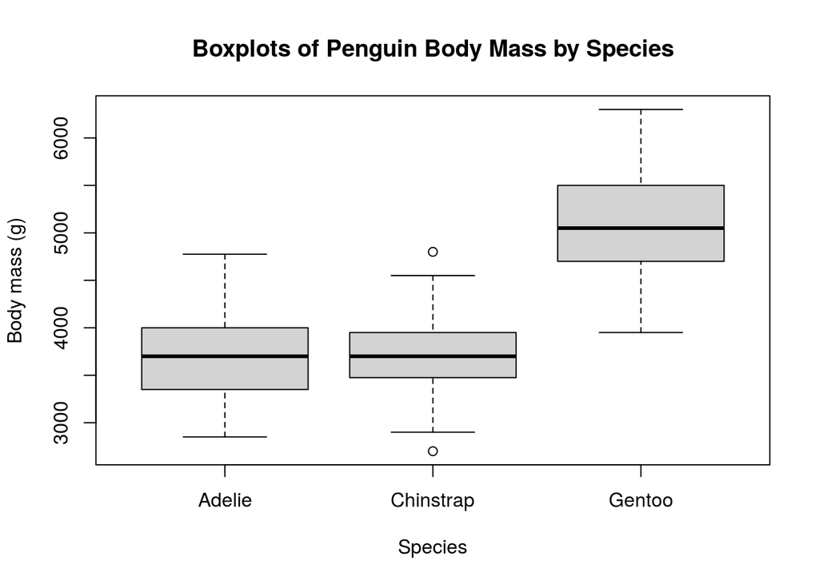

```r
boxplot(penguins$body_mass_g ~ penguins$species,
        main = "Boxplots of Penguin Body Mass by Species",
        ylab = "Body mass (g)",
        xlab = "Species")
```

Notice the `~` (tilde) in the code here. Think of this as the word “by”. In the code above, we’re making boxplots of penguin body mass *by* penguin species. Notice that we’re specifying the data set for each of these variables! If we didn’t, R wouldn’t know where to look for the variable.

We could also make boxplots of body mass by sex:

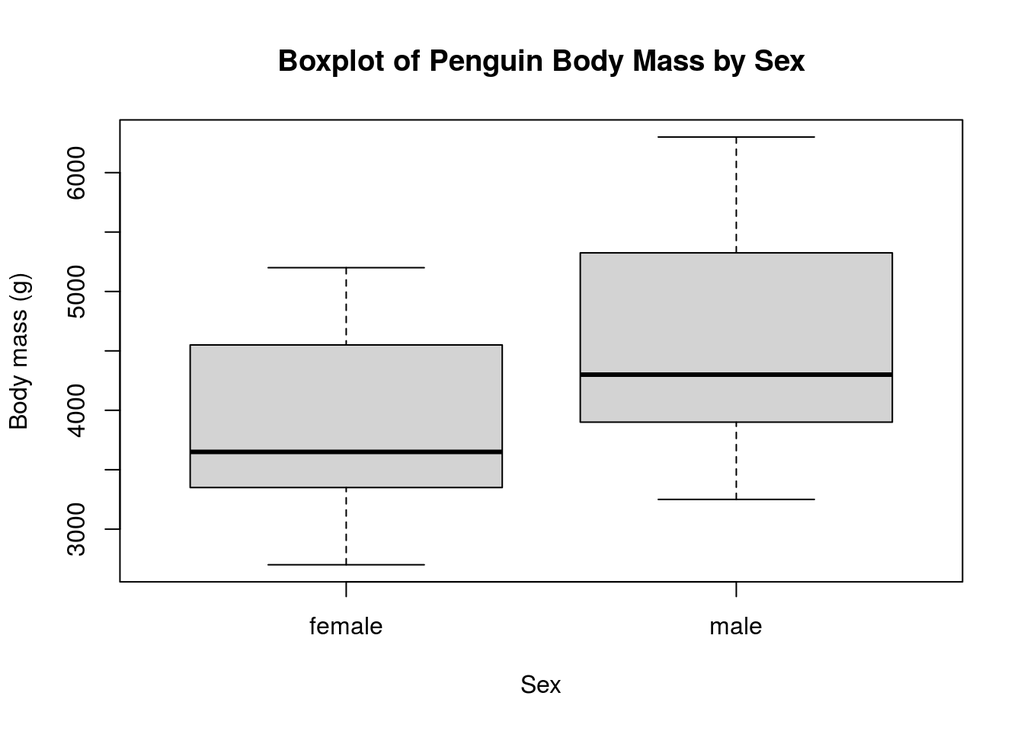

```r
boxplot(penguins$body_mass_g ~ penguins$sex,
        main = "Boxplot of Penguin Body Mass by Sex",
        ylab = "Body mass (g)",
        xlab = "Sex")
```

We could also avoid typing `penguins$` twice by giving `boxplot()` an argument called `data`. Here’s how that would look: (and notice that we gave this chunk a new name: bodyMassSex_**data** so that the document will knit)

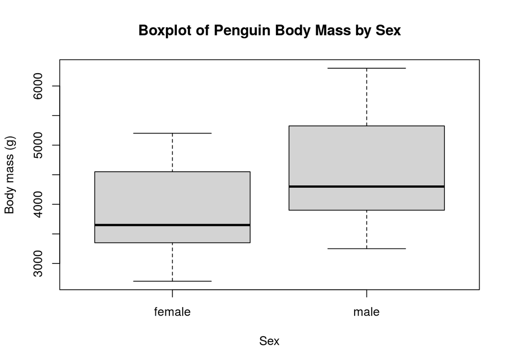

```r
boxplot(body_mass_g ~ sex,
        data = penguins,
        main = "Boxplot of Penguin Body Mass by Sex",
        ylab = "Body mass (g)",
        xlab = "Sex")
```

Be careful to note that using the `data` argument only works when you’re giving R a “formula” (the thing involving a tilde `~` – we’ll talk more about formulas later in the course).

Per usual, we can add colors to a plot using the `col` argument. Here’s that species plot again: (again, noticing that the chunk is renamed bodyMassSpecies_**colors**; chunk names must be unique for the document to knit)

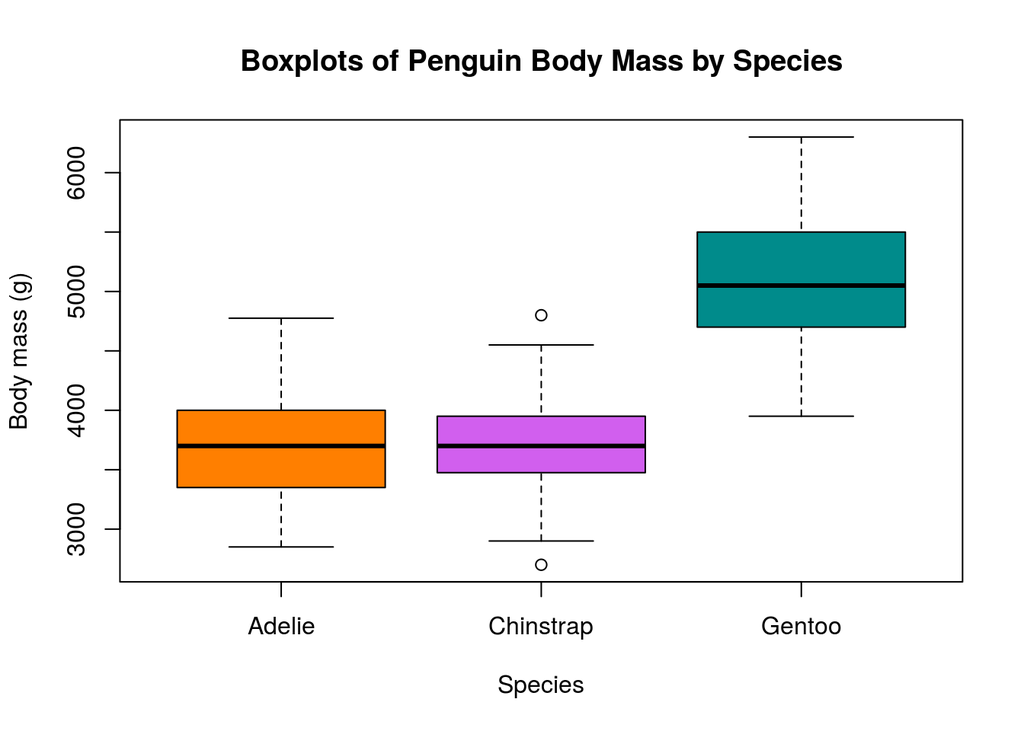

```r
boxplot(penguins$body_mass_g ~ penguins$species,
        main = "Boxplots of Penguin Body Mass by Species",
        ylab = "Body mass (g)",
        xlab = "Species",
        col = c("darkorange1", "mediumorchid2", "darkcyan")
)
```

**Note:** Notice that in each of our boxplots, the “by” variable (after the tilde `~`) is *categorical*. You *could* use a quantitative variable here, and R will give you a plot, but it’ll be weird looking. It’s *very* important to think about what you want out of your plots before writing R code because **you’re smarter than R.** Try this outside of lab: make a boxplot of body mass by bill length and see what happens. It’ll be gross.

### Histograms in R

Histograms in R are also pretty easy – you just use the `hist()` function.

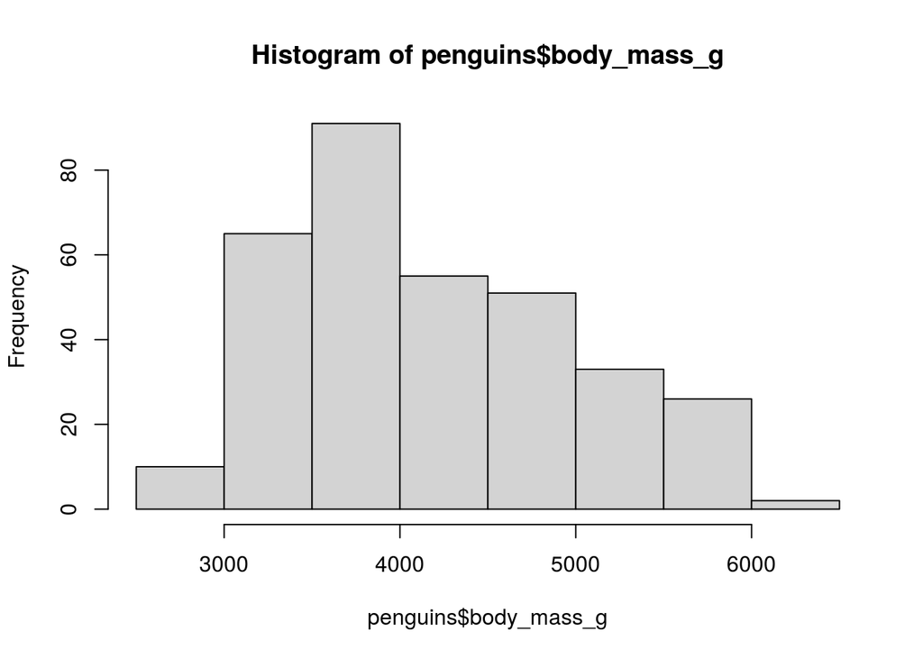

```r
hist(penguins$body_mass_g)
```

So here we’ve got a histogram. Notice that we didn’t provide the `main`, `xlab`, and `ylab` arguments that we’d normally use for a plot title and an axis label, but R still gave us a title and labels. This is nice, but the labels are *horrible*: nobody (other than you) knows what `penguins$body_mass_g` means, so we don’t want to use that as a title or axis label. The moral of the story is to *always provide `main`, `xlab`, and `ylab` arguments when making a plot!*

Here’s something better:

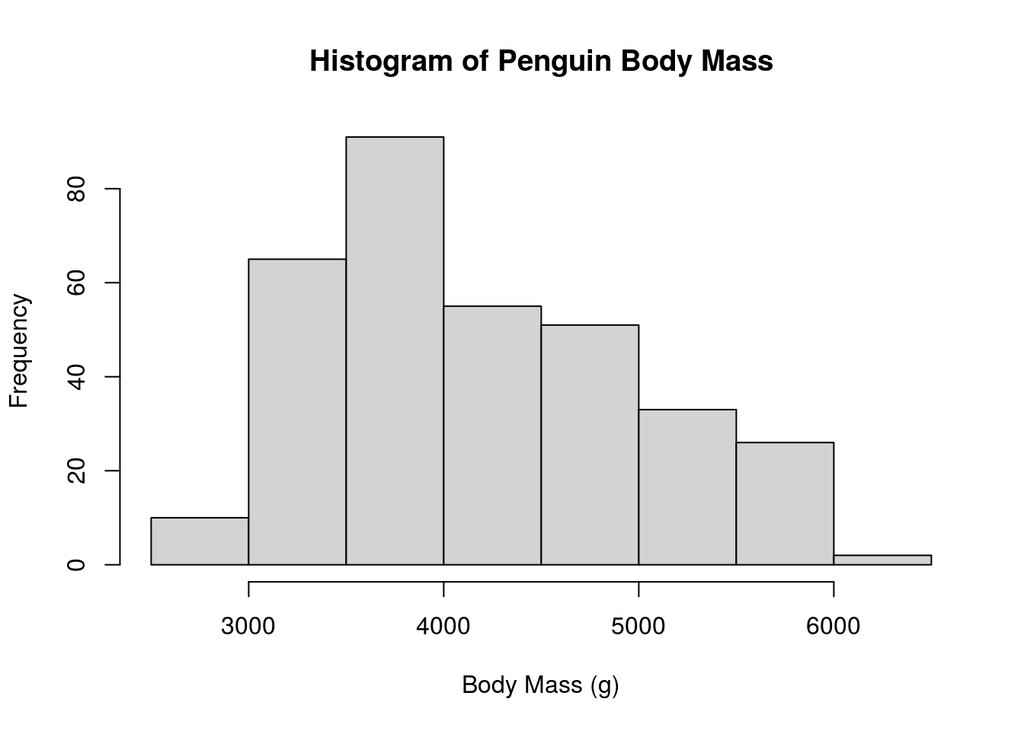

```r
hist(penguins$body_mass_g,
     main = "Histogram of Penguin Body Mass",
     xlab = "Body Mass (g)")
```

With histograms, it’s often helpful to change the number of bins to get a different view of the data. We can sort of control the number of bins using the `breaks` argument.

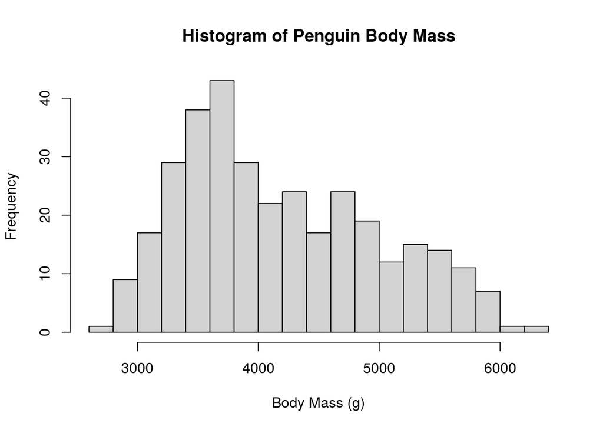

```r
hist(penguins$body_mass_g,
     main = "Histogram of Penguin Body Mass",
     xlab = "Body Mass (g)",
     breaks = 20)
```

So now we’ve got a lot more bins than in the original plot. There might not be exactly 20, though. R uses the `breaks` argument as a *suggestion* only – it’ll try to give you what you want, but (1) no promises and (2) it will prefer what it thinks is prettier. Your best strategy here is to play around with the number you give as `breaks` until you get a plot that looks “good”. Here’s what you’re looking for:

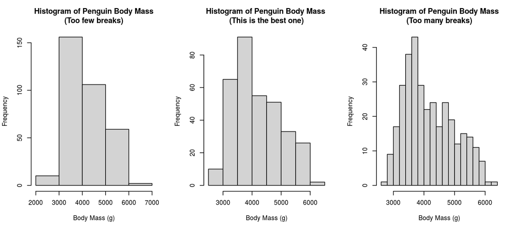

The middle plot (that uses the default number of breaks computed by R) is the best of these three. It gives you a good sense of the distribution of the values of body mass without being too fine or too coarse. This is something you’ll get the hang of as you see and make more histograms over the semester!

### How to find help in R

R has built-in “documentation” for every function. If you want to find that documentation, you can Google it, but that takes too long. So it’s better to use R’s built in help! In the R console, just type a question mark `?` followed by the name of the function you want help with, then hit enter. For example, `?hist` will bring up the documentation for the `hist()` function.

At the end of the help file you *may* find an example of how to use the function. These examples are generally super helpful! You can directly run them using the `example()` function – e.g., `example(hist)`.

The most useful feature of help is a list of a function’s arguments what they do. You may not be able to fully understand some of the terms in the documentation just yet, but try it out and your lab instructor will be able to help!

### Subsetting Data in R

Above, we made a histogram for the body mass of all penguins in our data set. Sometimes we want to break up our data into “subsets” so we can look at only data in a particular category (e.g., only Gentoo penguins). To do this, we can use the `subset()` function in R.

```r
gentooSubset <- subset(penguins, species == "Gentoo")
```

Here’s how the above code chunk works: the newly-created object `gentooSubset` *gets* (`<-`) the subset of `penguins` where the species variable is equal to “Gentoo”. So the first argument of `subset()` is the data frame you want to subset, and the second argument is the rule for which rows to take from the original data frame.

**Notice:** (1) we don’t need to write `penguins$species` in the second argument of `subset()` because we told R we’re working with `penguins` in the first argument; (2) the double equals (`==`) is *very* important in that second argument – make sure you use it when subsetting data!

```r
head(gentooSubset) # show the first few rows of gentoo
```

```
##     species island bill_length_mm bill_depth_mm flipper_length_mm body_mass_g
## 147  Gentoo Biscoe           46.1          13.2               211        4500
## 148  Gentoo Biscoe           50.0          16.3               230        5700
## 149  Gentoo Biscoe           48.7          14.1               210        4450
## 150  Gentoo Biscoe           50.0          15.2               218        5700
## 151  Gentoo Biscoe           47.6          14.5               215        5400
## 152  Gentoo Biscoe           46.5          13.5               210        4550
##        sex year
## 147 female 2007
## 148   male 2007
## 149 female 2007
## 150   male 2007
## 151   male 2007
## 152 female 2007
```

```r
table(gentooSubset$species) # show that we only have Gentoo penguins in gentoo
```

```
##
## Gentoo
##    119
```

So now we can make a histogram of body masses of just Gentoo penguins:

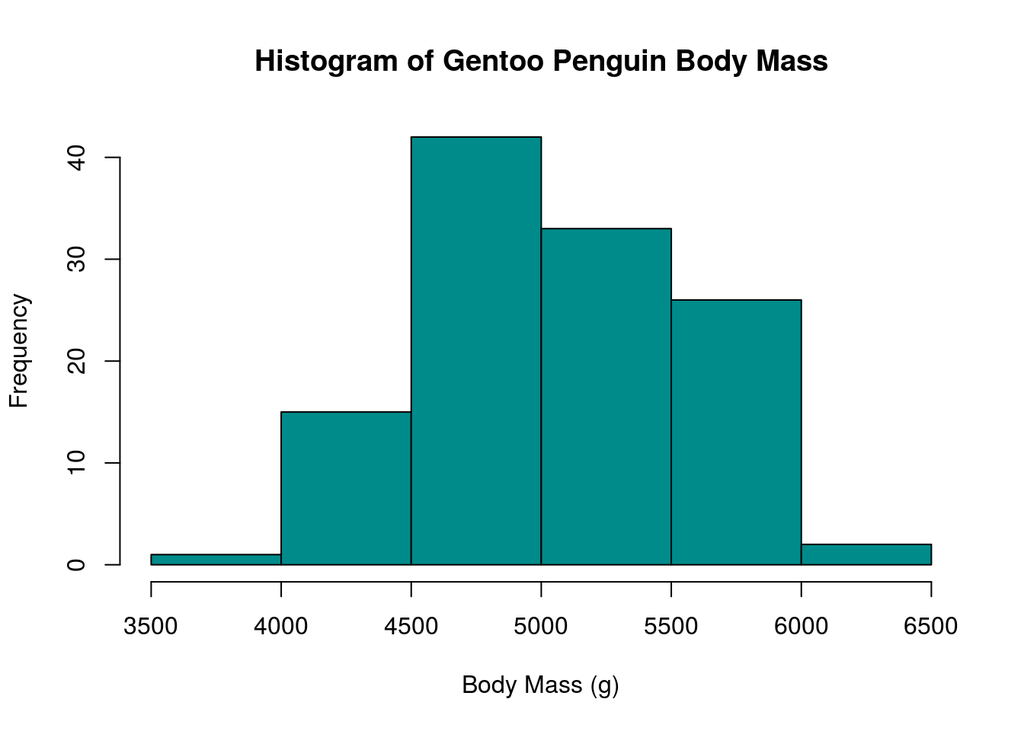

```r
hist(gentooSubset$body_mass_g,
     main = "Histogram of Gentoo Penguin Body Mass",
     xlab = "Body Mass (g)",
     col = "darkcyan")
```

## Try It!

Depending on your instruction method (in person, synchronous remote, asynchronous remote), complete the following exercises collaboratively.

1. **In person:** Form groups of 2-4 with those around you (maintaining physical distance). Your instructor will provide additional details.
2. **Synchronous remote:** You will be placed in a Zoom breakout room to work together in small groups.
3. **Asynchronous remote:** Join a Piazza lab group for asynchronous collaboration.

**Collaborators:** If applicable, replace this text with the names of anyone you collaborated with on this project.

In this Try It, we’ll be using a data set we will call `tuition` that contains information about cost of attendance for 1,861 colleges and universities around the United States.

> **1.** We’ll start by reading in the data. The data are stored in a file called `tuition_cost.csv`. You’ll need to give the name of this file (*in quotes!*) to `read.csv()`. When you read it in, call the data set `tuition`. **If you don’t call it `tuition` you’ll get errors later on.**

*Answer:*

```r
# Replace this comment with code required for Try It 1. (Remember that this text is a comment, so R ignores it; you can delete it if you want.)
```

> **2.** Before we make graphs or numerical summaries, give an overview of the data set in 2-3 sentences. Use whatever tools you like to preview the contents of the data. The goal is for you to understand what’s going on in the data set before working with it. Include any code in the chunk below. (*Disclaimer: There’s not a right or wrong answer here – just explore.*) You might want to revisit functions used in labs 1 and 2.

*Answer:*

```r
# Replace this comment with code required for Try It 2. (Remember that this text is a comment, so R ignores it; you can delete it if you want.)
```

Replace this text with your answer to Try It 2.

> **3.** Make a boxplot of the variable which represents the total cost of attendance (room and board + tuition) for in-state students. Be sure to give it an appropriate title, axis labels, etc. Based on this boxplot, does it appear that the data are symmetric?

*Answer:*

```r
# Replace this comment with code required for Try It 3. (Remember that this text is a comment, so R ignores it; you can delete it if you want.)
```

Replace this text with your answers to Try It 3.

> **4.** Make a histogram of the same variable from Try It 3, being sure to include a proper title and axis labels. Play around with the `breaks` argument until you’re satisfied with your histogram. Was your prediction about the symmetry of the data in Try It 3 accurate? In the future, do you think it’s always appropriate to describe shape based on a boxplot alone?

*Answer:*

```r
# Replace this comment with code required for Try It 4. (Remember that this text is a comment, so R ignores it; you can delete it if you want.)
```

Replace this text with your answers to Try It 4.

> **5.** Make a side-by-side boxplot of the total cost of attendance for in-state students by type of institution (for profit / public / private). As always, be sure to provide an appropriate title and axis labels. In 1-2 sentences, describe what you see.

*Answer:*

```r
# Replace this comment with code required for Try It 5. (Remember that this text is a comment, so R ignores it; you can delete it if you want.)
```

Replace this text with your answers to Try It 5.

> **6.** Subset the data to include only schools in Michigan and call the new subset `mi_tuition`. Make the same histogram as in Try It 4 using this subset of data. What do you notice about this histogram compared to the national histogram in Try It 4?

*Hint:* Remember that computers are dumb, and you need to type things *exactly* as they are in the data.

*Answer:*

```r
# Get started by copying and pasting the code in the above chunk called subset1. Replace this comment with any code you need to answer the question. (Remember that this text is a comment, so R ignores it; you can delete it if you want.)
```

Replace this text with your written answer to Try It 6.

## Dive Deeper

In the Try It, you played around a little with data about tuition costs. Now, we’re going to have you dive a little deeper.

> **1.** Review the histograms you created in Try It 4 and Try It 6 (national and Michigan-only in-state total cost of attendance). For each, do you *think* the median falls to the left or right of the mean, or is it approximately equal to the mean? After you’ve described your thinking, use R to verify your answer. (*It’s okay if your initial guesses were wrong. Don’t go back and change it based on R!*)

Replace this text with your thinking about means and medians *based only on histograms*

```r
# Use this code chunk to use R to find the appropriate mean and medians
```

Replace this text with your discussion of whether R confirmed your initial thinking.

> **2.** In the side-by-side boxplots you made in Try it 5, there’s an outlier in the boxplot for public institutions: the College of William and Mary. Give a 1-sentence reason you might keep this outlier in the data. Give a 1-sentence reason to eliminate the outlier. Which of your arguments is more compelling?

Replace this text with your written answer to the question.

[output not shown]

[output not shown]

*Write 1-2 sentences about your answer here*

## Wrap-Up and Submission

At the top of the document, make sure you’ve changed the `author` field to your name (in quotes!). If you’d like, change the date as well.

When you’ve finished the lab, click the **Knit** button one last time.

### Submission instructions

#### If you’re using RStudio Cloud

1. In the Files pane, check the box next to `lab03report.html`.
2. Click More > Export…
3. Click Download and save the file on your computer in a folder you’ll remember and be able to find later. You can just call the file `lab03report.html` or whatever else you’d like (as long as you remember what you called it).

#### If you’re using RStudio installed on your computer

1. locate the `lab03report.html` file on your computer. The file will be saved in the location indicated at the top of the files pane.

#### Submission to Canvas

1. Click the “Assignments” panel on the left side of the page. Scroll to find “Lab 3”, and open the assignment. Click “Submit Assignment”.
2. Towards the bottom of the page, you’ll be able to choose `lab03report.html` from the folder you saved it in from RStudio Cloud or noted if you’re using RStudio Desktop. **You will only be able to upload a .html file – do not upload any other file type.**
3. Click “Submit Assignment”. You’re done!